# MA331-Report: 2211560

TED Talks by Speaker Ueli Gegenschatz and Speaker Herbie Hancock

Shah, Musawer

# Introduction

In this report I will analyse two ted talks transcripts that has been assigned to me. The two talks are **Extreme wingsuit flying** and **An all-star set**.

This first talk was given by **Ueli Gegenschatz** in **April 2009**. In this Talk, He shares his experiences as an extreme wingsuit flyer, and the lessons he learned for these sports. He try to experience the sport in different ways like sky diving, jumping from a moving truck, wingsuit diving, and from different other places and formats. In this talk he gave how to push your limits upto the full extent.

The second talk was given by **Herbi Hancock** in **Jan 2010**. This talks don’t have a lot of speaking, instead it was more of a musical type where he deliver a powerful performance with two of his other friend.

# Methods

In this report, I had first loaded the data of TED TALKS from **dsEssex** library and then filter it according to the speaker I had be assigned with. After that I had removed the unnecassary words *stopwords* and show some basic summary of the most frequent words they had used. After than I visualize the top words they had used using **ggplot** library both collectively and individually. Then I compare the most frequent words of both speaker and present it in the graph. And then finally I had make a deeper comparison between the two speakers by sentimentally analysing it and visualization the Log odds ratio side by side.

# Results

### Filter Ted Talks

First I filter the ted talks data for my assigned speakers and gave a basic insight into data using `head` function.

```
# A tibble: 2 × 5
  talk_id headline                text                            speaker  views
    <dbl> <chr>                   <chr>                           <chr>    <dbl>
1     502 Extreme wingsuit flying "I started with paragliding. P… Ueli G… 1.49e6
2     729 An all-star set         "(Music)    (Applause)    (Mus… Herbie… 6.82e5
```

### Flat data into tidy format and remove stopwords.

Then i change the text column of my data into tidy word column using `unnest_tokens` function, and also remove the stopwords using `anti_join`.

```
# A tibble: 6 × 5
  talk_id headline                speaker            views word
    <dbl> <chr>                   <chr>              <dbl> <chr>
1     502 Extreme wingsuit flying Ueli Gegenschatz 1487217 started
2     502 Extreme wingsuit flying Ueli Gegenschatz 1487217 paragliding
3     502 Extreme wingsuit flying Ueli Gegenschatz 1487217 paragliding
4     502 Extreme wingsuit flying Ueli Gegenschatz 1487217 taking
5     502 Extreme wingsuit flying Ueli Gegenschatz 1487217 mountains
6     502 Extreme wingsuit flying Ueli Gegenschatz 1487217 paraglider
```

### Summary of Words Used.

Then i counted the words used by each speaker and print it in descending order.

**Ueli Gegenschatz most frequent words**

```
# A tibble: 298 × 2
   word          n
   <chr>     <int>
 1 can          11
 2 jc            9
 3 jump          9
 4 ue            9
 5 flying        8
 6 much          8
 7 see           8
 8 wingsuit      8
 9 skydiving     7
10 fly           6
# ℹ 288 more rows
```

**Herbi Hancock most frequent words**

```
# A tibble: 10 × 2
   word         n
   <chr>    <int>
 1 applause     7
 2 music        4
 3 thank        3
 4 hancock      1
 5 harvey       1
 6 herbie       1
 7 marcus       1
 8 mason        1
 9 miller       1
10 much         1
```

### Visualization of frequent words by both speaker.

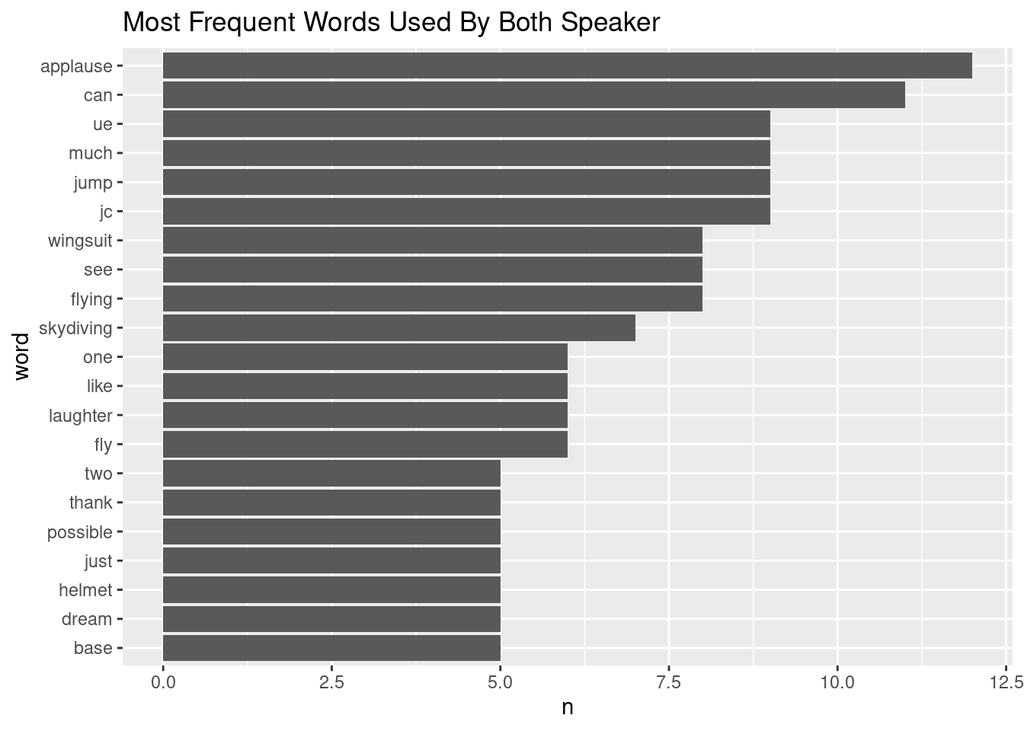

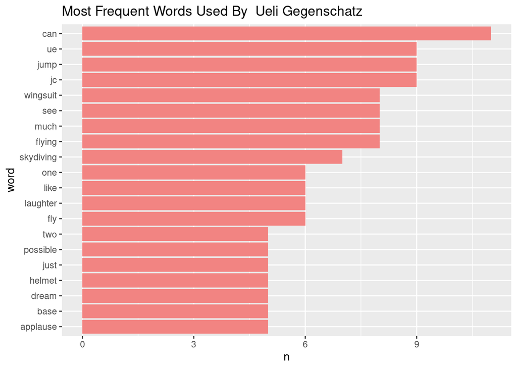

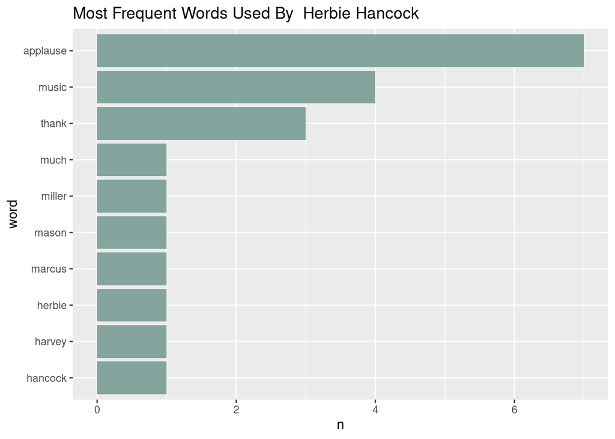

### Comparing most frequent words of both speakers.

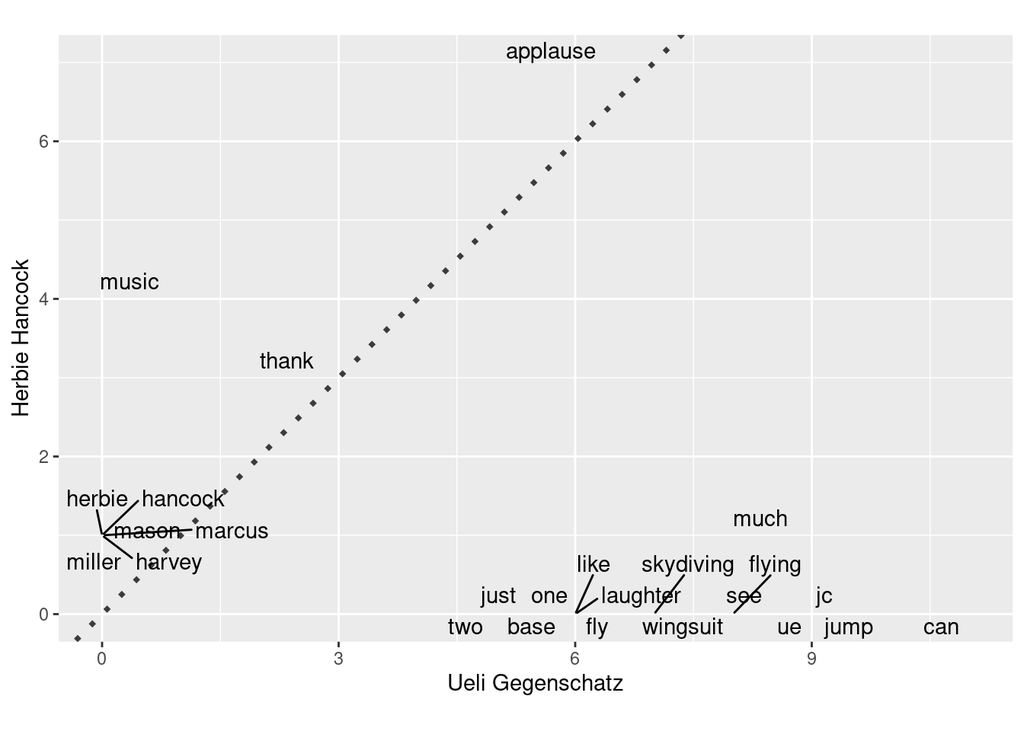

### Showing sentiment of each word by Ueli Gegenschatz

```
# A tibble: 218 × 6
   talk_id headline                speaker            views word       sentiment
     <dbl> <chr>                   <chr>              <dbl> <chr>      <chr>
 1     502 Extreme wingsuit flying Ueli Gegenschatz 1487217 possibili… anticipa…
 2     502 Extreme wingsuit flying Ueli Gegenschatz 1487217 cross      anger
 3     502 Extreme wingsuit flying Ueli Gegenschatz 1487217 cross      fear
 4     502 Extreme wingsuit flying Ueli Gegenschatz 1487217 cross      negative
 5     502 Extreme wingsuit flying Ueli Gegenschatz 1487217 cross      sadness
 6     502 Extreme wingsuit flying Ueli Gegenschatz 1487217 flying     fear
 7     502 Extreme wingsuit flying Ueli Gegenschatz 1487217 flying     positive
 8     502 Extreme wingsuit flying Ueli Gegenschatz 1487217 helmet     fear
 9     502 Extreme wingsuit flying Ueli Gegenschatz 1487217 helmet     positive
10     502 Extreme wingsuit flying Ueli Gegenschatz 1487217 jump       joy
# ℹ 208 more rows
```

### Showing sentiment of each word by Herbi Hancock

```
# A tibble: 40 × 6
   talk_id headline        speaker         views word     sentiment
     <dbl> <chr>           <chr>           <dbl> <chr>    <chr>
 1     729 An all-star set Herbie Hancock 681930 music    joy
 2     729 An all-star set Herbie Hancock 681930 music    positive
 3     729 An all-star set Herbie Hancock 681930 music    sadness
 4     729 An all-star set Herbie Hancock 681930 applause joy
 5     729 An all-star set Herbie Hancock 681930 applause positive
 6     729 An all-star set Herbie Hancock 681930 applause surprise
 7     729 An all-star set Herbie Hancock 681930 applause trust
 8     729 An all-star set Herbie Hancock 681930 music    joy
 9     729 An all-star set Herbie Hancock 681930 music    positive
10     729 An all-star set Herbie Hancock 681930 music    sadness
# ℹ 30 more rows
```

### Odds Ratio & Odds Ration of Sentiment for Ueli Gegenschatz & Herbi Hancock

In the below code I had also replaced the value of 0 from **Herbie Hancock** sentiments with a small value of 0.5 in order to avoid divide by zero in Odds Ratio

```
# A tibble: 10 × 5
   sentiment    `Herbie Hancock` `Ueli Gegenschatz`     OR log_OR
   <fct>                   <dbl>              <int>  <dbl>  <dbl>
 1 joy                      11                   30  0.457 -0.783
 2 positive                 11                   66  1.24   0.218
 3 sadness                   4                    7  0.319 -1.14
 4 surprise                  7                   14  0.348 -1.06
 5 trust                     7                   27  0.717 -0.333
 6 anger                     0.5                  7  2.79   1.02
 7 anticipation              0.5                 28 12.4    2.52
 8 disgust                   0.5                  3  1.17   0.159
 9 fear                      0.5                 24 10.4    2.34
10 negative                  0.5                 12  4.89   1.59
```

### Visualize the logs_OR of sentiments of both speaker.

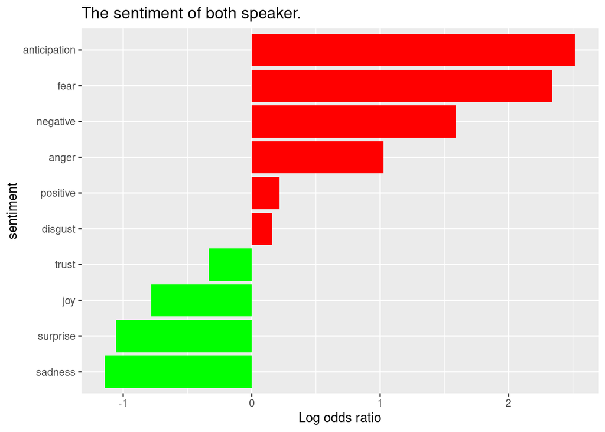

### Visualize words & log_OR in different sentiment

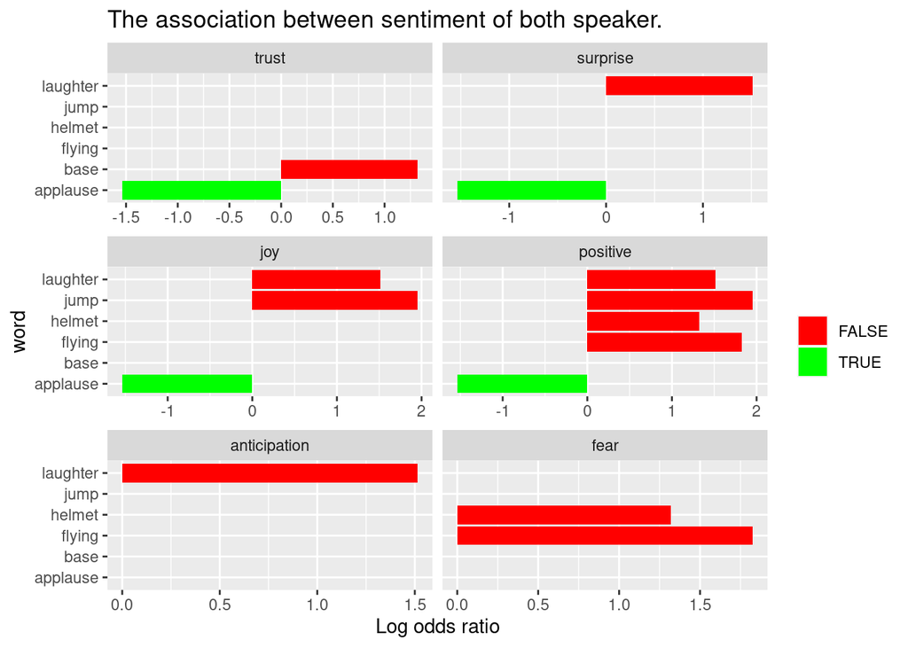